# Final Project

Data Science for Biologists, Spring 2021

Stephanie Sanders

## Introduction

This [data](https://github.com/BuzzFeedNews/2018-03-oscars-script-diversity-analysis/blob/master/data/actor-metrics.csv) is all of the relevant information of the films nominated for Best Picture at the Oscars in 1989, 2015, and 2017. The data will be used to analyze the progression of diversity in Best Picture-nominated films.

```r
oscars <- read_csv("sanders_actor-metrics.csv") #data from the 1989, 2015 and 2017 oscars
dplyr::glimpse(oscars)
```

```
## Rows: 265
## Columns: 10
## $ year        <dbl> 1989, 1989, 1989, 1989, 1989, 1989, 1989, 1989, 1989, 198…
## $ film        <chr> "born-on-the-fourth-of-july", "born-on-the-fourth-of-july…
## $ actor       <chr> "Dale Dye", "David Warshofsky", "Frank Whaley", "Jerry Le…
## $ characters  <chr> "COLONEL", "LIEUTENANT", "TIMMY", "STEVE", "KENNEDY", "TO…
## $ imdb        <chr> "http://www.imdb.com/name/nm0245653/", "http://www.imdb.c…
## $ gender      <chr> "male", "male", "male", "male", "male", "male", "female",…
## $ race        <chr> "White/Caucasian", "White/Caucasian", "White/Caucasian", …
## $ race_simple <chr> "White", "White", "White", "White", "White", "White", "Wh…
## $ words       <dbl> 216, 290, 104, 300, 217, 140, 188, 366, 161, 348, 189, 25…
## $ sentences   <dbl> 15, 40, 14, 35, 5, 22, 30, 34, 16, 45, 20, 48, 15, 18, 26…
```

```r
oscars %>%
  select(race) %>%
  distinct() #show which races are represented in the data
```

```
## # A tibble: 5 x 1
##   race
##   <chr>
## 1 White/Caucasian
## 2 Black/African American
## 3 2+ Race
## 4 Asian
## 5 Hispanic/Latino
```

## Question 1

#### Has there been an increase in the representation of people of color (POC) in Oscar-nominated films for Best Picture?

### Methods

```r
oscars %>%
  select(-actor, -characters, -imdb) -> oscars_condensed
```

```r
oscars_condensed %>%
  select(year, film, race_simple) %>%
  group_by(year, film) %>%
  filter(race_simple == "POC") %>%
  count() %>%
  rename(number_poc = n) -> poc_by_film #number of POC by film

oscars_condensed %>%
  select(year, film, race_simple) %>%
  group_by(year, film) %>%
  count() %>%
  rename(number_actors = n) -> actors_by_film #number of actors by film

full_join(poc_by_film, actors_by_film) %>%
  mutate(percent_poc = number_poc/number_actors * 100) %>% #percentage of POC by film
  arrange(desc(percent_poc)) %>%
  group_by(year) %>%
  slice(1) %>%
  ungroup() %>%
  transform(year = factor(year,
                              levels = c(1989, 2015, 2017),
                              labels = c("1989", "2015", "2017"))) %>% #change year values to strings for fill purposes on plot
  select(year, film, percent_poc) -> percent_poc_film
```

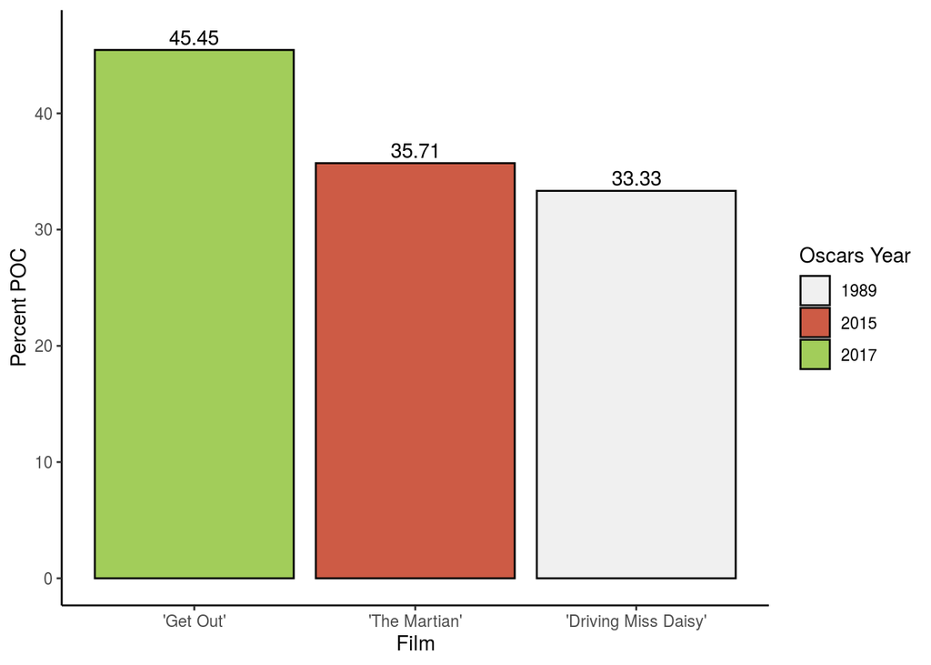

```r
eighty_nine <- "gray94"
fifteen <- "coral3"
seventeen <- "darkolivegreen3"
yearfill <- c(eighty_nine, fifteen, seventeen) #fun fact, these are roughly the colors that were the most popular for each year
film_names <- fct_relevel(c("'Driving Miss Daisy'", "'The Martian'", "'Get Out'")) #fix the titles of the movies
theme_set(theme_classic())

percent_poc_film %>%
  ggplot() +
  aes(x = fct_reorder(film_names, percent_poc, .desc = TRUE), #order films by percentage
      y = percent_poc,
      fill = year) +
  geom_col(color = "black") +
  scale_fill_manual(values = yearfill, name = "Oscars Year") + #fill columns by year
  geom_text(aes(x = film_names,
                y = percent_poc + 1.1,
                label = round(percent_poc, digits = 2))) +
  labs(x = "Film",
       y = "Percent POC")
```

### Answer

Based on the films with the highest percentage of POC actors from each year, there has been an increase in POC representation. From 1989 to 2015, there was only a 2.38% increase in POC actors the between the most diverse Best Picture-nominated films from each year. From 2015 to 2017, there was a 9.74% increase in POC actors the between the most diverse Best Picture-nominated films from each year.

## Question 2

#### Over the three years provided, which non-white race is the most represented in Oscar-nominated films for Best Picture? Which race is the least represented in Oscar-nominated films for Best Picture?

### Methods

```r
oscars_condensed %>%
  count() -> total_actors

sum(total_actors$n) -> total

oscars_condensed %>%
  select(race) %>%
  group_by(race) %>%
  filter(race != "White/Caucasian") %>% #remove "White/Caucasian"
  count() %>%
  rename(number_poc = n) %>%
  mutate(percent_poc = number_poc / sum(total)*100) %>% #percent race representation
  select(-number_poc) -> poc_overall
```

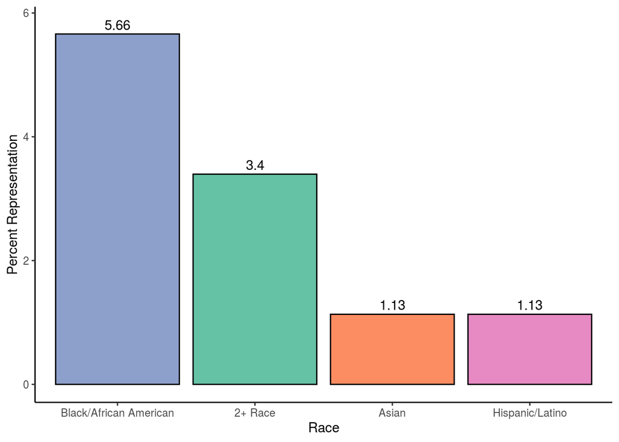

```r
poc_overall %>%
  ggplot() +
  aes(x = fct_reorder(race, percent_poc, .desc = TRUE), #order films by percentage
      y = percent_poc,
      fill = race) +
  geom_col(color = "black") +
  geom_text(aes(x = race,
                y = percent_poc + 0.15,
                label = round(percent_poc, digits = 2))) +
  scale_fill_brewer(palette = "Set2") +
  theme(legend.position = "none") +
  labs(x = "Race",
       y = "Percent Representation")
```

### Answer

African Americans are the most represented non-white race, making up 5.66% of all actors in Best Picture Oscar-nominated films for these years. The least represented races are Asian and Hispanic/Latio, each making up 1.13% of of all actors in Best Picture Oscar-nominated films for these years.

## Question 3

#### Over time, has there been an increase in the number of sentences spoken by POC actors in Oscar-nominated films for Best Picture?

### Methods

```r
sum(oscars_condensed$sentences) -> total_sentences

oscars_condensed %>%
  select(year, race_simple, sentences) %>%
  group_by(race_simple) %>%
  filter(race_simple != "White") %>% #remove "White"
  ungroup() %>%
  group_by(year) %>%
  summarize(poc_sentences_total = sum(sentences)) %>%
  mutate(percent_poc_sentences = (poc_sentences_total/total_sentences)*100) %>% #percent lines each year
  transform(year = factor(year,
                              levels = c(1989, 2015, 2017),
                              labels = c("1989", "2015", "2017"))) %>% #change year values to strings for fill purposes on plot
  select(-poc_sentences_total) -> poc_sentences_by_year
```

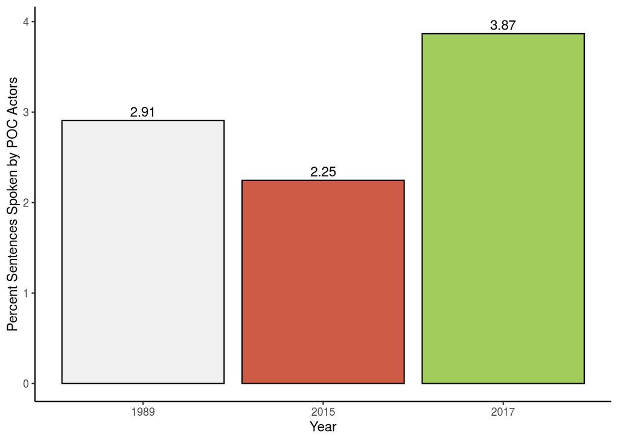

```r
poc_sentences_by_year %>%
  ggplot() +
  aes(x = year, #order years by percentage
      y = percent_poc_sentences,
      fill = year) +
  geom_col(color = "black") +
  geom_text(aes(x = year,
                y = percent_poc_sentences + 0.1,
                label = round(percent_poc_sentences, digits = 2))) +
  scale_fill_manual(values = yearfill, name = "Oscars Year") + #fill columns by year
  theme(legend.position = "none") +
  labs(x = "Year",
       y = "Percent Sentences Spoken by POC Actors")
```

### Answer

There does not appear to be an upward trend in the number of lines given to POC actors across the years in Best Picture-nominated films. Of the Best Picture-nominated films in 2017, POC actors had 3.87% of the lines. In 2015, only 2.25% of lines were given to POC actors and 2.91% of lines in 1989. Overall, all of these percentages are very low and seem to vary based on the specific films being nominated that year and not by any progression of diversity.

## Question 4

#### Which year had the most even ratio of male to female actors in Oscar-nominated films for Best Picture?

### Methods

```r
oscars_condensed %>%
  select(year, gender) %>%
  group_by(year, gender) %>%
  tally %>%
  mutate(ratio = n/sum(n)) %>%
  transform(year = factor(year,
                              levels = c(1989, 2015, 2017),
                              labels = c("1989", "2015", "2017"))) %>% #change year values to strings for fill purposes on plot
  select(-n) -> gender_by_year
```

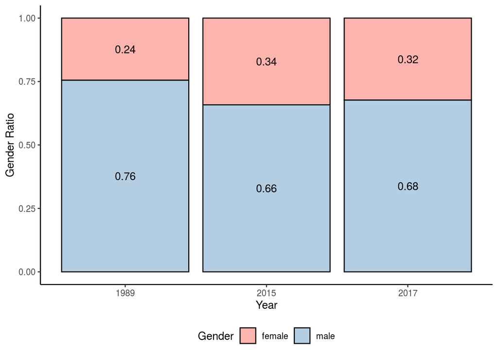

```r
gender_by_year %>%
  ggplot() +
  aes(x = year,
      y = ratio,
      fill = gender) +
  geom_bar(position = "stack", stat = "identity", color = "black") +
  theme(legend.position = "bottom") +
  scale_fill_brewer(palette = "Pastel1", name = "Gender") +
  geom_text(aes(x = year,
                y = ratio,
                label = round(ratio, digits = 2)),
            position = position_stack(vjust = 0.5)) +
  labs(x = "Year",
       y = "Gender Ratio")
```

### Answer

Based off of the graph, 2015 had the most even male to female ratio at 66% men with 2017 close behind at 68% men. Between 1989 and 2015, there was a 10% decrease in the amount of male actors in Oscar-nominated films for Best Picture. The 2% increase in 2017 likely isn’t significant, given how small this increase is.